# Project: Investigate TMDb movie data

- Introduction
  - Dataset Intro
  - Questions
- Data Wrangling
  - Observations
  - Data Cleaning
- Exploratory Data Analysis
  - Which genres are most popular from year to year?
  - What kinds of properties are associated with movies that have high revenues?
  - What kinds of properties are associated with movies that have high revenues? (Accounting for Inflation)
  - What is the film with the highest budget each year?
- Conclusions

## Introduction

> **Tip**: In this section of the report, provide a brief introduction to the dataset you've selected for analysis. At the end of this section, describe the questions that you plan on exploring over the course of the report. Try to build your report around the analysis of at least one dependent variable and three independent variables. If you're not sure what questions to ask, then make sure you familiarize yourself with the dataset, its variables and the dataset context for ideas of what to explore.

### Dataset Intro

I chose to work with the TMDB dataset.

This data set contains information about 10,000 movies collected from The Movie Database (TMDb), including user ratings and revenue.

> **General Info about this dataset**:
> - It has a total of 10866 rows and 21 columns
> - Certain columns, ('cast', 'director', 'keywords', 'genres', 'production_companies'), contain multiple values separated by pipe (|) characters.
> - There are some odd characters in the ‘cast’ column. Don’t worry about cleaning them. We can leave them as is. (There are some characters like those in the 'director' column as well.
> - The final two columns ending with “_adj” show the budget and revenue of the associated movie in terms of 2010 dollars, accounting for inflation over time

### Interesting Questions

1. Which genres are most popular from year to year?
1. What kinds of properties are associated with movies that have high revenues?
1. Does higher average vote (rating) corellate with higher revenues? (we can check for this using raw revenues or revenues_adj to account for inflation)
1. What is the film with the highest budget each year?

### Notice

I use the explode() function in this notebook, so the following code cell makes sure that the needed pandas version is installed.

> After this code cell runs, please restart the kernel

```python
# I use this command to update pandas because i use the explode() function which is new in pandas 0.25.0
!pip3 install --user --upgrade pandas
```

```python
# Let's get done with the imports
import pandas as pd
import numpy as np
import matplotlib.pyplot as plt
import itertools
%matplotlib inline
```

```python
# Function Definition
def plot(df=None, x=None, y=None, type='bar', figsize=(15,8), title="", xlabel="", ylabel="", width=1.5, xticks=None,
         colormap=None, rot=None, table=None):
    """
    plot function: takes a dataframe with specifications like type, title, axes labels
    and plots the dataframe following the provided specs
    """
    if type != 'line' and type != 'pie':
        return df.plot(x=x, y=y, kind=type, figsize=figsize, title=title, xlabel=xlabel, ylabel=ylabel,
                width=width, xticks=xticks, rot=rot, colormap=colormap)
    elif type=='pie':
        return df.plot(x=x, y=y, kind=type, figsize=figsize, title=title, xlabel=xlabel, ylabel=ylabel,
                xticks=xticks, rot=rot, colormap=colormap, table=table)
    else:
        return df.plot(x=x, y=y, kind=type, figsize=figsize, title=title, xlabel=xlabel, ylabel=ylabel,
                xticks=xticks, rot=rot, colormap=colormap)
```

## Data Wrangling

> **Tip**: In this section of the report, you will load in the data, check for cleanliness, and then trim and clean your dataset for analysis. Make sure that you document your steps carefully and justify your cleaning decisions.

### General Properties

```python
# Use wget to download the csv file from the server. "-nc" command prevents wget from downloading the file if it already exists
!wget -nc https://d17h27t6h515a5.cloudfront.net/topher/2017/October/59dd1c4c_tmdb-movies/tmdb-movies.csv
```

```
File ‘tmdb-movies.csv’ already there; not retrieving.
```

```python
# Load your data and print out a few lines. Perform operations to inspect data
# types and look for instances of missing or possibly errant data.

df = pd.read_csv("tmdb-movies.csv")
pd.set_option('display.max_columns', None)
df.head()
```

|  | id | imdb_id | popularity | budget | revenue | original_title | cast | homepage | director | tagline | keywords | overview | runtime | genres | production_companies | release_date | vote_count | vote_average | release_year | budget_adj | revenue_adj |
| --- | --- | --- | --- | --- | --- | --- | --- | --- | --- | --- | --- | --- | --- | --- | --- | --- | --- | --- | --- | --- | --- |
| 0 | 135397 | tt0369610 | 32.985763 | 150000000 | 1513528810 | Jurassic World | Chris Pratt\|Bryce Dallas Howard\|Irrfan Khan\|Vi... | http://www.jurassicworld.com/ | Colin Trevorrow | The park is open. | monster\|dna\|tyrannosaurus rex\|velociraptor\|island | Twenty-two years after the events of Jurassic ... | 124 | Action\|Adventure\|Science Fiction\|Thriller | Universal Studios\|Amblin Entertainment\|Legenda... | 6/9/15 | 5562 | 6.5 | 2015 | 1.379999e+08 | 1.392446e+09 |
| 1 | 76341 | tt1392190 | 28.419936 | 150000000 | 378436354 | Mad Max: Fury Road | Tom Hardy\|Charlize Theron\|Hugh Keays-Byrne\|Nic... | http://www.madmaxmovie.com/ | George Miller | What a Lovely Day. | future\|chase\|post-apocalyptic\|dystopia\|australia | An apocalyptic story set in the furthest reach... | 120 | Action\|Adventure\|Science Fiction\|Thriller | Village Roadshow Pictures\|Kennedy Miller Produ... | 5/13/15 | 6185 | 7.1 | 2015 | 1.379999e+08 | 3.481613e+08 |
| 2 | 262500 | tt2908446 | 13.112507 | 110000000 | 295238201 | Insurgent | Shailene Woodley\|Theo James\|Kate Winslet\|Ansel... | http://www.thedivergentseries.movie/#insurgent | Robert Schwentke | One Choice Can Destroy You | based on novel\|revolution\|dystopia\|sequel\|dyst... | Beatrice Prior must confront her inner demons ... | 119 | Adventure\|Science Fiction\|Thriller | Summit Entertainment\|Mandeville Films\|Red Wago... | 3/18/15 | 2480 | 6.3 | 2015 | 1.012000e+08 | 2.716190e+08 |
| 3 | 140607 | tt2488496 | 11.173104 | 200000000 | 2068178225 | Star Wars: The Force Awakens | Harrison Ford\|Mark Hamill\|Carrie Fisher\|Adam D... | http://www.starwars.com/films/star-wars-episod... | J.J. Abrams | Every generation has a story. | android\|spaceship\|jedi\|space opera\|3d | Thirty years after defeating the Galactic Empi... | 136 | Action\|Adventure\|Science Fiction\|Fantasy | Lucasfilm\|Truenorth Productions\|Bad Robot | 12/15/15 | 5292 | 7.5 | 2015 | 1.839999e+08 | 1.902723e+09 |
| 4 | 168259 | tt2820852 | 9.335014 | 190000000 | 1506249360 | Furious 7 | Vin Diesel\|Paul Walker\|Jason Statham\|Michelle ... | http://www.furious7.com/ | James Wan | Vengeance Hits Home | car race\|speed\|revenge\|suspense\|car | Deckard Shaw seeks revenge against Dominic Tor... | 137 | Action\|Crime\|Thriller | Universal Pictures\|Original Film\|Media Rights ... | 4/1/15 | 2947 | 7.3 | 2015 | 1.747999e+08 | 1.385749e+09 |

```python
df.shape
```

```
(10866, 21)
```

```python
df.describe()
```

|  | id | popularity | budget | revenue | runtime | vote_count | vote_average | release_year | budget_adj | revenue_adj |
| --- | --- | --- | --- | --- | --- | --- | --- | --- | --- | --- |
| count | 10866.000000 | 10866.000000 | 1.086600e+04 | 1.086600e+04 | 10866.000000 | 10866.000000 | 10866.000000 | 10866.000000 | 1.086600e+04 | 1.086600e+04 |
| mean | 66064.177434 | 0.646441 | 1.462570e+07 | 3.982332e+07 | 102.070863 | 217.389748 | 5.974922 | 2001.322658 | 1.755104e+07 | 5.136436e+07 |
| std | 92130.136561 | 1.000185 | 3.091321e+07 | 1.170035e+08 | 31.381405 | 575.619058 | 0.935142 | 12.812941 | 3.430616e+07 | 1.446325e+08 |
| min | 5.000000 | 0.000065 | 0.000000e+00 | 0.000000e+00 | 0.000000 | 10.000000 | 1.500000 | 1960.000000 | 0.000000e+00 | 0.000000e+00 |
| 25% | 10596.250000 | 0.207583 | 0.000000e+00 | 0.000000e+00 | 90.000000 | 17.000000 | 5.400000 | 1995.000000 | 0.000000e+00 | 0.000000e+00 |
| 50% | 20669.000000 | 0.383856 | 0.000000e+00 | 0.000000e+00 | 99.000000 | 38.000000 | 6.000000 | 2006.000000 | 0.000000e+00 | 0.000000e+00 |
| 75% | 75610.000000 | 0.713817 | 1.500000e+07 | 2.400000e+07 | 111.000000 | 145.750000 | 6.600000 | 2011.000000 | 2.085325e+07 | 3.369710e+07 |
| max | 417859.000000 | 32.985763 | 4.250000e+08 | 2.781506e+09 | 900.000000 | 9767.000000 | 9.200000 | 2015.000000 | 4.250000e+08 | 2.827124e+09 |

```python
df.info()
```

```
<class 'pandas.core.frame.DataFrame'>
RangeIndex: 10866 entries, 0 to 10865
Data columns (total 21 columns):
 #   Column                Non-Null Count  Dtype
---  ------                --------------  -----
 0   id                    10866 non-null  int64
 1   imdb_id               10856 non-null  object
 2   popularity            10866 non-null  float64
 3   budget                10866 non-null  int64
 4   revenue               10866 non-null  int64
 5   original_title        10866 non-null  object
 6   cast                  10790 non-null  object
 7   homepage              2936 non-null   object
 8   director              10822 non-null  object
 9   tagline               8042 non-null   object
 10  keywords              9373 non-null   object
 11  overview              10862 non-null  object
 12  runtime               10866 non-null  int64
 13  genres                10843 non-null  object
 14  production_companies  9836 non-null   object
 15  release_date          10866 non-null  object
 16  vote_count            10866 non-null  int64
 17  vote_average          10866 non-null  float64
 18  release_year          10866 non-null  int64
 19  budget_adj            10866 non-null  float64
 20  revenue_adj           10866 non-null  float64
dtypes: float64(4), int64(6), object(11)
memory usage: 1.7+ MB
```

```
array([[<matplotlib.axes._subplots.AxesSubplot object at 0x7fab1f241ef0>,
      dtype=object)
```

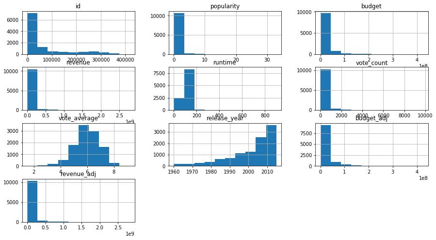

```python
df.hist(figsize=(15,8))
```

```python
#let's check the movies with 0 runtime
df[df['runtime']==0]
```

|  | id | imdb_id | popularity | budget | revenue | original_title | cast | homepage | director | tagline | keywords | overview | runtime | genres | production_companies | release_date | vote_count | vote_average | release_year | budget_adj | revenue_adj |
| --- | --- | --- | --- | --- | --- | --- | --- | --- | --- | --- | --- | --- | --- | --- | --- | --- | --- | --- | --- | --- | --- |
| 92 | 370687 | tt3608646 | 1.876037 | 0 | 0 | Mythica: The Necromancer | Melanie Stone\|Adam Johnson\|Kevin Sorbo\|Nicola ... | http://www.mythicamovie.com/#!blank/y9ake | A. Todd Smith | NaN | sword\|magic\|sorcery\|necromancer | Mallister takes Thane prisoner and forces Mare... | 0 | Fantasy\|Action\|Adventure | Arrowstorm Entertainment\|Camera 40 Productions... | 12/19/15 | 11 | 5.4 | 2015 | 0.000000e+00 | 0.0 |
| 334 | 361931 | tt5065822 | 0.357654 | 0 | 0 | Ronaldo | Cristiano Ronaldo | http://www.ronaldothefilm.com | Anthony Wonke | Astonishing. Intimate. Definitive. | biography\|soccer player | Filmed over 14 months with unprecedented acces... | 0 | Documentary | On The Corner Films\|We Came, We Saw, We Conque... | 11/9/15 | 80 | 6.5 | 2015 | 0.000000e+00 | 0.0 |
| 410 | 339342 | tt2948712 | 0.097514 | 0 | 0 | Anarchy Parlor | Robert LaSardo\|Jordan James Smith\|Sara Fabel\|T... | NaN | Kenny Gage\|Devon Downs | NaN | tattoo\|tattooing | Six young college hopefuls vacationing and par... | 0 | Horror | NaN | 1/1/15 | 15 | 5.6 | 2015 | 0.000000e+00 | 0.0 |
| 445 | 353345 | tt3800796 | 0.218528 | 0 | 0 | The Exorcism of Molly Hartley | Sarah Lind\|Devon Sawa\|Gina Holden\|Peter MacNei... | NaN | Steven R. Monroe | NaN | NaN | Taking place years after The Haunting of Molly... | 0 | Horror | WT Canada Productions | 10/9/15 | 52 | 5.0 | 2015 | 0.000000e+00 | 0.0 |
| 486 | 333653 | tt4058368 | 0.176744 | 0 | 0 | If There Be Thorns | Heather Graham\|Jason Lewis\|Rachael Carpani\|Mas... | NaN | Nancy Savoca | NaN | woman director | The third installment in V.C. Andrews’ bests... | 0 | TV Movie\|Drama | A+E Studios\|Jane Startz Productions | 4/5/15 | 11 | 5.4 | 2015 | 0.000000e+00 | 0.0 |
| 595 | 341051 | tt2914740 | 0.028725 | 0 | 0 | Deep Dark | Sean McGrath\|Denise Poirier\|Anne Sorce\|Tabor H... | http://deepdarkmovie.com | Michael Medaglia | NaN | NaN | Fantasy - A failed sculptor discovers a strang... | 0 | Horror | NaN | 1/1/15 | 11 | 4.6 | 2015 | 0.000000e+00 | 0.0 |
| 616 | 325843 | tt4333210 | 0.026797 | 0 | 0 | The Outfield | Cameron Dallas\|Hamilton Nash Grier\|Olivia Stuc... | NaN | Michael Goldfine | NaN | NaN | The film follows a trio of varsity baseball pl... | 0 | Drama\|Comedy | NaN | 11/10/15 | 20 | 6.6 | 2015 | 0.000000e+00 | 0.0 |
| 1241 | 296370 | tt3024964 | 0.135376 | 0 | 0 | Dance-Off | Kathryn McCormick\|Shane Harper\|Finola Hughes\|C... | NaN | NaN | NaN | dance\|dance-off | DANCE-OFF is a tongue-in-cheek family comedy s... | 0 | Romance\|Music\|Comedy | NaN | 1/1/14 | 18 | 5.7 | 2014 | 0.000000e+00 | 0.0 |
| 1289 | 286372 | tt1791681 | 0.037459 | 3250000 | 0 | Treehouse | J. Michael Trautmann\|Dana Melanie\|Daniel Fredr... | http://www.imdb.com/title/tt1791681/ | Michael G. Bartlett | No kids allowed | kidnapping\|brutality\|violence\|teenager\|discovery | A teenage boy discovers the perpetrators of se... | 0 | Thriller\|Horror\|Mystery | Tiberius Film | 10/20/14 | 16 | 3.4 | 2014 | 2.993546e+06 | 0.0 |
| 1293 | 286256 | tt3134058 | 0.036904 | 0 | 0 | Tim Maia | Robson Nunes\|Babú Santana\|Alinne Moraes\|Cauã... | NaN | Mauro Lima | Original language PORTUGUESE | brazilian\|biography\|music\|drama\|documentary | Biopic of Brazilian singer Tim Maia, from his ... | 0 | Documentary\|Drama\|Music | Globo Filmes | 10/30/14 | 14 | 6.0 | 2014 | 0.000000e+00 | 0.0 |
| 1849 | 18247 | tt1212986 | 0.120350 | 0 | 0 | Spectacular! | Nolan Gerard Funk\|Jesse Moss\|Britt Irvin\|Tammi... | NaN | Robert Iscove | NaN | NaN | A high school choir is fading in popularity, a... | 0 | Drama\|Music | NaN | 2/16/09 | 13 | 5.2 | 2009 | 0.000000e+00 | 0.0 |
| 2315 | 48373 | tt1274296 | 0.171615 | 0 | 0 | Listen to Your Heart | Alexia Rasmussen\|Kent Moran\|Cybill Shepherd\|Sh... | http://www.listentoyourheartfilm.com/ | NaN | One song can change your life. | independent film | Danny Foster doesn't have much: an apartment a... | 0 | Drama\|Music\|Romance | NaN | 8/14/10 | 29 | 7.3 | 2010 | 0.000000e+00 | 0.0 |
| 2370 | 127717 | tt1525359 | 0.081892 | 0 | 0 | Freshman Father | Britt Irvin\|Merrilyn Gann\|Barbara Tyson\|Anthon... | NaN | Michael Scott | NaN | NaN | NaN | 0 | NaN | NaN | 6/5/10 | 12 | 5.8 | 2010 | 0.000000e+00 | 0.0 |
| 3329 | 20414 | tt1077026 | 0.082898 | 0 | 0 | Grande, grosso e Verdone | Carlo Verdone\|Claudia Gerini\|Eva Riccobono\|Vit... | NaN | Carlo Verdone | NaN | NaN | No overview found. | 0 | Family | Filmauro | 3/7/08 | 35 | 5.3 | 2008 | 0.000000e+00 | 0.0 |
| 3794 | 58253 | tt1588335 | 0.183134 | 0 | 0 | Toi, moi, les autres | Leïla Bekhti\|Benjamin Siksou\|Cécile Cassel\|C... | http://www.google.fr/m/url?ei=e3BxTcjeLMqB8wP6... | Audrey Estrougo | NaN | woman director | NaN | 0 | Music\|Romance | NaN | 2/22/11 | 17 | 5.2 | 2011 | 0.000000e+00 | 0.0 |
| 3857 | 289097 | tt1288636 | 0.095583 | 0 | 0 | Cell 213 | Bruce Greenwood\|Eric Balfour\|Michael Rooker\|De... | NaN | Stephen Kay | NaN | NaN | Cocky young attorney Michael Gray finds himsel... | 0 | Horror | Access Motion Pictures | 6/10/11 | 13 | 5.2 | 2011 | 0.000000e+00 | 0.0 |
| 3884 | 105885 | tt1754944 | 0.045198 | 0 | 0 | eCupid | Houston Rhines\|Andy Anderson\|John Callahan\|Gal... | NaN | J.C. Calciano | NaN | gay couple | From the director of Is It Just Me? comes this... | 0 | Romance | NaN | 6/23/11 | 12 | 4.6 | 2011 | 0.000000e+00 | 0.0 |
| 4063 | 28004 | tt0359639 | 0.371510 | 6000000 | 0 | Madea's Family Reunion | Tyler Perry\|Blair Underwood\|Lynn Whitfield\|Bor... | NaN | Tyler Perry | NaN | NaN | Just as the southern matriarch, Madea buries h... | 0 | Comedy | NaN | 1/25/02 | 49 | 5.9 | 2002 | 7.273568e+06 | 0.0 |
| 4138 | 44266 | tt0242953 | 0.035895 | 0 | 0 | A Time for Dancing | Larisa Oleynik\|Shiri Appleby\|Peter Coyote\|Patr... | NaN | Peter Gilbert | NaN | NaN | Their love of dance, and their friendship, is ... | 0 | Drama\|Music | NaN | 9/6/02 | 14 | 7.5 | 2002 | 0.000000e+00 | 0.0 |
| 4829 | 110490 | tt1910605 | 0.140016 | 0 | 0 | Rags | Keke Palmer\|Avan Jogia\|Drake Bell\|Burkely Duff... | NaN | Bille Woodruff | NaN | musical | Rags follows the story of Charlie Prince, an o... | 0 | TV Movie\|Comedy\|Drama | NaN | 5/28/12 | 24 | 5.7 | 2012 | 0.000000e+00 | 0.0 |
| 4944 | 158150 | tt2395247 | 0.026459 | 0 | 0 | How to Fall in Love | Brooke D'Orsay\|Eric Mabius\|Jody Thompson\|Gina ... | NaN | Mark Griffiths | NaN | NaN | An accountant, who never quite grew out of his... | 0 | Comedy\|Romance\|TV Movie | Annuit Coeptis Entertainment Inc.\|Annuit Coept... | 7/21/12 | 11 | 4.7 | 2012 | 0.000000e+00 | 0.0 |
| 5216 | 28003 | tt0427481 | 0.073665 | 0 | 0 | Madea's Class Reunion | Tyler Perry\|Chandra Currelley\|Cheryl Pepsii Ri... | NaN | Tyler Perry | NaN | NaN | Madea is traveling to the Pandora Hotel, where... | 0 | Comedy\|Music | NaN | 6/25/03 | 12 | 6.9 | 2003 | 0.000000e+00 | 0.0 |
| 5695 | 224815 | tt2881698 | 0.417739 | 0 | 0 | Skinwalker Ranch | Steve Berg\|Kyle Davis\|Erin Cahill\|Jon Gries\|De... | NaN | Devin McGinn | NaN | NaN | In 2010 “Skinwalker Ranch” gained media at... | 0 | Thriller\|Horror\|Science Fiction | DeepStudios | 10/30/13 | 27 | 4.3 | 2013 | 0.000000e+00 | 0.0 |
| 5920 | 248842 | tt2364006 | 0.165765 | 0 | 0 | The Food Guide to Love | Richard Coyle\|Leonor Watling\|Ginés García Mi... | NaN | Dominic Harari\|Teresa Pelegri | NaN | woman director | A dysfunctional love story about an Irish food... | 0 | Romance\|Comedy | Haut et Court\|Parallel Film Productions\|Fox In... | 12/18/13 | 12 | 5.6 | 2013 | 0.000000e+00 | 0.0 |
| 5938 | 191562 | tt2436516 | 0.147188 | 0 | 0 | Go Goa Gone | Saif Ali Khan\|Anand Tiwari\|Vir Das\|Pooja Gupta | NaN | Krishna D.K.\|Raj Nidimoru | NaN | hindi\|zombies island\|zombies\|zombie survival | A rave party off the coast of Goa, goes horrif... | 0 | Comedy\|Horror | Eros International | 5/10/13 | 16 | 5.3 | 2013 | 0.000000e+00 | 0.0 |
| 5992 | 173847 | tt2343371 | 0.096455 | 0 | 0 | Amiche da morire | Claudia Gerini\|Cristiana Capotondi\|Sabrina Imp... | NaN | Giorgia Farina | NaN | NaN | Three very different women who are hiding a se... | 0 | Romance\|Crime\|Comedy | NaN | 3/7/13 | 30 | 5.5 | 2013 | 0.000000e+00 | 0.0 |
| 6040 | 202604 | tt3043194 | 0.011798 | 0 | 0 | The Vatican Exorcisms | Joe Marino | NaN | Joe Marino | The public were never meant to know | exorcism | Documentary following US film-maker Joe Marino... | 0 | Horror\|Documentary\|Mystery | NaN | 5/29/13 | 10 | 4.7 | 2013 | 0.000000e+00 | 0.0 |
| 6383 | 26985 | tt0405615 | 0.371630 | 2000000 | 0 | The 12 Dogs of Christmas | Jordan-Claire Green\|Tom Kemp\|Susan Wood\|Adam H... | NaN | Kieth Merrill | NaN | holiday | This holiday tale has all the elements of a cl... | 0 | Drama\|Family | NaN | 11/1/05 | 11 | 4.7 | 2005 | 2.233127e+06 | 0.0 |
| 6552 | 13739 | tt0448245 | 0.006440 | 0 | 0 | Quatre étoiles | José Garcia\|Isabelle Carré\|Renée Le Calm\|Fr... | NaN | Christian Vincent | NaN | NaN | No overview found. | 0 | Comedy | NaN | 1/1/05 | 15 | 5.9 | 2005 | 0.000000e+00 | 0.0 |
| 6934 | 13713 | tt0477988 | 0.071872 | 0 | 0 | Jean-Philippe | Fabrice Luchini\|Johnny Hallyday\|Jackie Berroye... | NaN | Laurent Tuel | NaN | NaN | No overview found. | 0 | Comedy | Fidélité Productions\|StudioCanal\|TF1 Films P... | 4/5/06 | 26 | 5.6 | 2006 | 0.000000e+00 | 0.0 |
| 8874 | 46406 | tt0248185 | 0.069903 | 0 | 0 | Mission Kashmir | Sanjay Dutt\|Hrithik Roshan\|Preity Zinta\|Jackie... | NaN | Vidhu Vinod Chopra | NaN | NaN | A police officer adopts the son and sole survi... | 0 | Action\|Drama\|Foreign | NaN | 10/27/00 | 10 | 5.7 | 2000 | 0.000000e+00 | 0.0 |